# Potential Loan Taker Prediction

### Domain

Banking

### Context:

This case is about a bank (Thera Bank) whose management wants to explore ways of converting its liability customers to personal loan customers (while retaining them as depositors). A campaign that the bank ran last year for liability customers showed a healthy conversion rate of over 9% success. This has encouraged the retail marketing department to devise campaigns with better target marketing to increase the success ratio with minimal budget.

### Objective:

The classification goal is to predict the likelihood of a liability customer buying personal loans.

## 1. Read the column description and ensure you understand each attribute well

```python
# import necessary libraries

import numpy as np
import pandas as pd
import matplotlib.pyplot as plt
%matplotlib inline
import seaborn as sns
```

```python
# read the data

pLoan = pd.read_csv("Bank_Personal_Loan_Modelling.csv")
```

```python
pLoan.head()
```

|  | ID | Age | Experience | Income | ZIP Code | Family | CCAvg | Education | Mortgage | Personal Loan | Securities Account | CD Account | Online | CreditCard |
| --- | --- | --- | --- | --- | --- | --- | --- | --- | --- | --- | --- | --- | --- | --- |
| 0 | 1 | 25 | 1 | 49 | 91107 | 4 | 1.6 | 1 | 0 | 0 | 1 | 0 | 0 | 0 |
| 1 | 2 | 45 | 19 | 34 | 90089 | 3 | 1.5 | 1 | 0 | 0 | 1 | 0 | 0 | 0 |
| 2 | 3 | 39 | 15 | 11 | 94720 | 1 | 1.0 | 1 | 0 | 0 | 0 | 0 | 0 | 0 |
| 3 | 4 | 35 | 9 | 100 | 94112 | 1 | 2.7 | 2 | 0 | 0 | 0 | 0 | 0 | 0 |
| 4 | 5 | 35 | 8 | 45 | 91330 | 4 | 1.0 | 2 | 0 | 0 | 0 | 0 | 0 | 1 |

### Attribute Information

- **ID** : Customer ID
- **Age** : Customer's age in completed years
- **Experience** : #years of professional experience
- **Income** : Annual income of the customer
- **ZIP Code** : Home Address ZIP code.
- **Family** : Family size of the customer
- **CCAvg** : Avg. spending on credit cards per month
- **Education** : Education Level (1:Undergrad; 2: Graduate; 3: Advanced/Professional)
- **Mortgage** : Value of house mortgage if any.
- **Personal Loan** : Did this customer accept the personal loan offered in the last campaign?
- **Securities Account** : Does the customer have a securities account with the bank?
- **CD Account** : Does the customer have a certificate of deposit (CD) account with the bank?
- **Online** : Does the customer use internet banking facilities?
- **Credit card** : Does the customer use a credit card issued by UniversalBank?

#### Categorical attributes

1. ZIP Code
2. Family
3. Education
4. Securities Account
5. CD Account
6. Online
7. Credit Card

#### Numerical Attributes

1. Age
2. Experience
3. Income
4. CCAvg
5. Mortagage

#### Target Attribute

Personal Loan

## 2. Study the data distribution in each attribute.

```python
pLoan.info()
```

```
<class 'pandas.core.frame.DataFrame'>
RangeIndex: 5000 entries, 0 to 4999
Data columns (total 14 columns):
ID                    5000 non-null int64
Age                   5000 non-null int64
Experience            5000 non-null int64
Income                5000 non-null int64
ZIP Code              5000 non-null int64
Family                5000 non-null int64
CCAvg                 5000 non-null float64
Education             5000 non-null int64
Mortgage              5000 non-null int64
Personal Loan         5000 non-null int64
Securities Account    5000 non-null int64
CD Account            5000 non-null int64
Online                5000 non-null int64
CreditCard            5000 non-null int64
dtypes: float64(1), int64(13)
memory usage: 547.0 KB
```

```python
print("Missing values if any (True/False)? :", pLoan.isnull().values.any())
pLoan.isna().apply(pd.value_counts)
```

```
Missing values if any (True/False)? : False
```

|  | ID | Age | Experience | Income | ZIP Code | Family | CCAvg | Education | Mortgage | Personal Loan | Securities Account | CD Account | Online | CreditCard |
| --- | --- | --- | --- | --- | --- | --- | --- | --- | --- | --- | --- | --- | --- | --- |
| False | 5000 | 5000 | 5000 | 5000 | 5000 | 5000 | 5000 | 5000 | 5000 | 5000 | 5000 | 5000 | 5000 | 5000 |

**From the above results, it is clear that the data doesnot have any missing values or null values**

```python
pLoan.describe().T
```

|  | count | mean | std | min | 25% | 50% | 75% | max |
| --- | --- | --- | --- | --- | --- | --- | --- | --- |
| ID | 5000.0 | 2500.500000 | 1443.520003 | 1.0 | 1250.75 | 2500.5 | 3750.25 | 5000.0 |
| Age | 5000.0 | 45.338400 | 11.463166 | 23.0 | 35.00 | 45.0 | 55.00 | 67.0 |
| Experience | 5000.0 | 20.104600 | 11.467954 | -3.0 | 10.00 | 20.0 | 30.00 | 43.0 |
| Income | 5000.0 | 73.774200 | 46.033729 | 8.0 | 39.00 | 64.0 | 98.00 | 224.0 |
| ZIP Code | 5000.0 | 93152.503000 | 2121.852197 | 9307.0 | 91911.00 | 93437.0 | 94608.00 | 96651.0 |
| Family | 5000.0 | 2.396400 | 1.147663 | 1.0 | 1.00 | 2.0 | 3.00 | 4.0 |
| CCAvg | 5000.0 | 1.937938 | 1.747659 | 0.0 | 0.70 | 1.5 | 2.50 | 10.0 |
| Education | 5000.0 | 1.881000 | 0.839869 | 1.0 | 1.00 | 2.0 | 3.00 | 3.0 |
| Mortgage | 5000.0 | 56.498800 | 101.713802 | 0.0 | 0.00 | 0.0 | 101.00 | 635.0 |
| Personal Loan | 5000.0 | 0.096000 | 0.294621 | 0.0 | 0.00 | 0.0 | 0.00 | 1.0 |
| Securities Account | 5000.0 | 0.104400 | 0.305809 | 0.0 | 0.00 | 0.0 | 0.00 | 1.0 |
| CD Account | 5000.0 | 0.060400 | 0.238250 | 0.0 | 0.00 | 0.0 | 0.00 | 1.0 |
| Online | 5000.0 | 0.596800 | 0.490589 | 0.0 | 0.00 | 1.0 | 1.00 | 1.0 |
| CreditCard | 5000.0 | 0.294000 | 0.455637 | 0.0 | 0.00 | 0.0 | 1.00 | 1.0 |

#### Deductions:

**Attribute 'Experience' is seen to have negative values which is not ideal.**  
**So we replace the negative values with median of the Experience.**

```python
# First let us find out the median of Experience.

med_exp = pLoan.loc[:,"Experience"].median()
print("Median of Experience attribute :", med_exp)

pLoan.loc[:,"Experience"].replace([-1,-2,-3] , [med_exp,med_exp,med_exp], inplace=True)

print("Any negative value in Experience column (True/False)? :", any(pLoan["Experience"]<0))
print("Minimun value in Experience Column :", pLoan.loc[:,"Experience"].min())
```

```
Median of Experience attribute : 20.0
Any negative value in Experience column (True/False)? : False
Minimun value in Experience Column : 0.0
```

**Now we see there are no negative values in Experience column**

### Analysis of Numerical Attributes

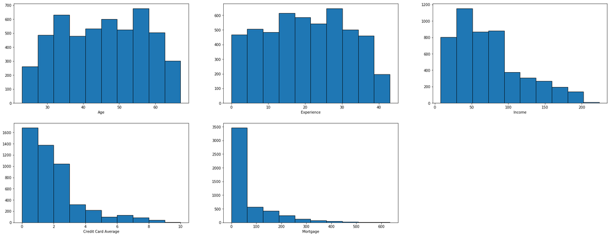

```python
plt.figure(figsize= (30,30))
plt.subplot(5,3,1)
plt.hist(pLoan.Age, edgecolor = 'black')
plt.xlabel('Age')

plt.subplot(5,3,2)
plt.hist(pLoan.Experience,edgecolor = 'black')
plt.xlabel('Experience')

plt.subplot(5,3,3)
plt.hist(pLoan.Income,edgecolor = 'black')
plt.xlabel('Income')

plt.subplot(5,3,4)
plt.hist(pLoan.CCAvg,edgecolor = 'black')
plt.xlabel('Credit Card Average')

plt.subplot(5,3,5)
plt.hist(pLoan.Mortgage,edgecolor = 'black')
plt.xlabel('Mortgage')

plt.show()
```

#### Deductions :

1. Age and Experience are normally distrubuted
2. The other attributes appear to be highly skewed

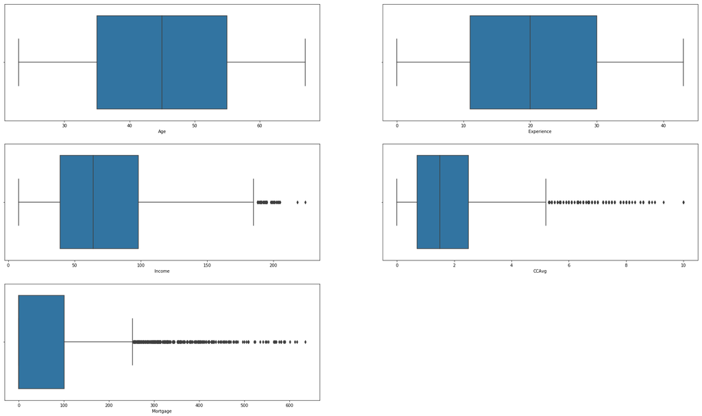

```python
plt.figure(figsize= (30,30))
plt.subplot(5,2,1)
sns.boxplot(x= pLoan.Age)

plt.subplot(5,2,2)
sns.boxplot(x= pLoan.Experience)

plt.subplot(5,2,3)
sns.boxplot(x= pLoan.Income)

plt.subplot(5,2,4)
sns.boxplot(x= pLoan.CCAvg)

plt.subplot(5,2,5)
sns.boxplot(x= pLoan.Mortgage)
```

### Analysis of Categorical variables

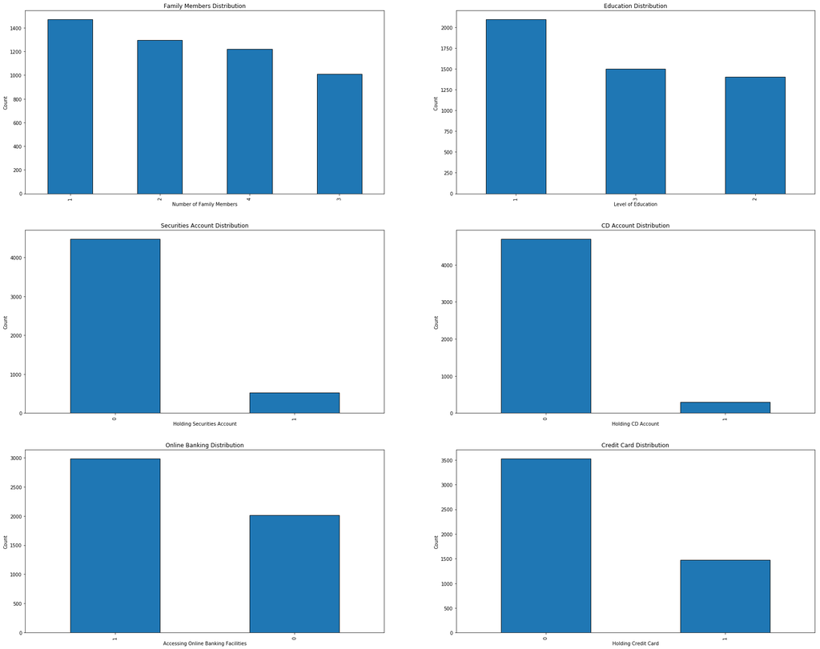

```python
plt.figure(figsize=(30,50))

plt.subplot(6,2,1)
pLoan['Family'].value_counts().plot(kind="bar", align='center',edgecolor = 'black')
plt.xlabel("Number of Family Members")
plt.ylabel("Count")
plt.title("Family Members Distribution")

plt.subplot(6,2,2)
pLoan['Education'].value_counts().plot(kind="bar", align='center',edgecolor = 'black')
plt.xlabel('Level of Education')
plt.ylabel('Count ')
plt.title('Education Distribution')

plt.subplot(6,2,3)
pLoan['Securities Account'].value_counts().plot(kind="bar", align='center',edgecolor = 'black')
plt.xlabel('Holding Securities Account')
plt.ylabel('Count')
plt.title('Securities Account Distribution')

plt.subplot(6,2,4)
pLoan['CD Account'].value_counts().plot(kind="bar", align='center',edgecolor = 'black')
plt.xlabel('Holding CD Account')
plt.ylabel('Count')
plt.title("CD Account Distribution")

plt.subplot(6,2,5)
pLoan['Online'].value_counts().plot(kind="bar", align='center',edgecolor = 'black')
plt.xlabel('Accessing Online Banking Facilities')
plt.ylabel('Count')
plt.title("Online Banking Distribution")

plt.subplot(6,2,6)
pLoan['CreditCard'].value_counts().plot(kind="bar", align='center',edgecolor = 'black')
plt.xlabel('Holding Credit Card')
plt.ylabel('Count')
plt.title("Credit Card Distribution")
```

#### Deductions:

1. Family memebers and Education attributes are almost evenly distrubuted.
2. We see most of the customers are not holding a Securities account or CD account.
3. A close to even split between no.of customers accesing online facilities and those not using it.

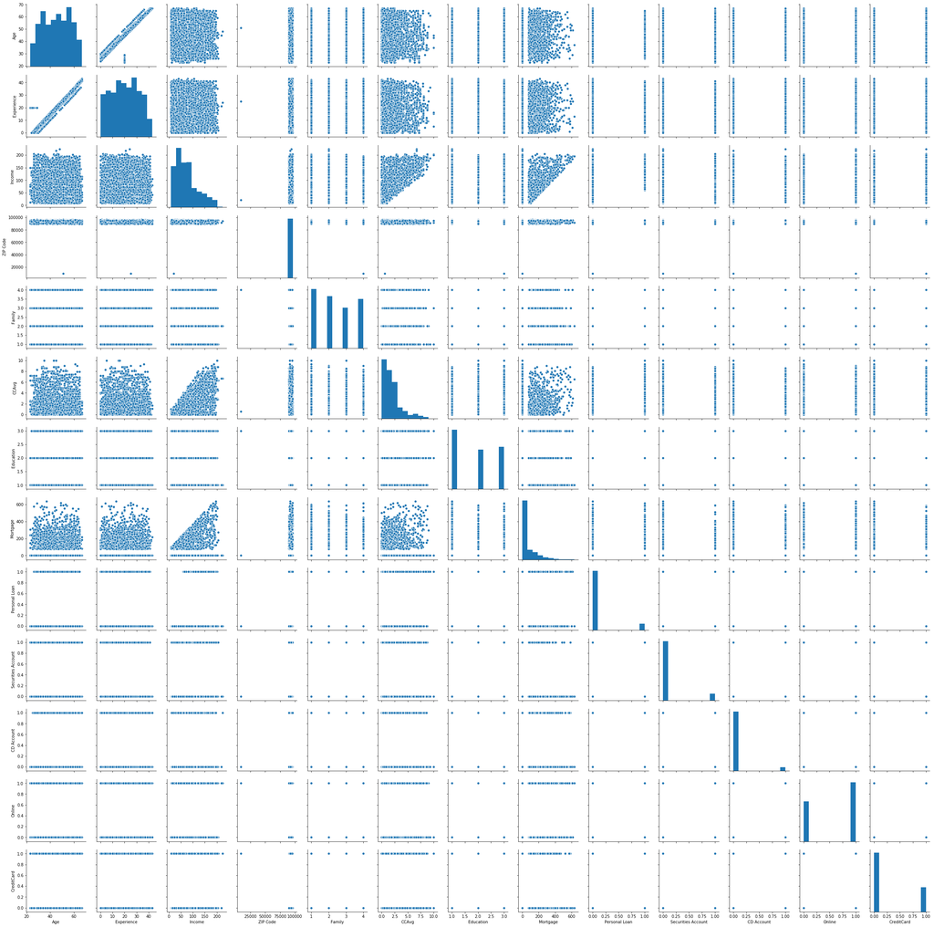

```python
# pair plot to visualise the correlations between all the attributes.
#to do this we do not want the ID column. Hence we select second column onwards.

sns.pairplot(pLoan.iloc[:, 1:])
```

### Deductions:

Age has a linear correlation with Experience.

## 3. Target attribute analysis

```python
pLoan['Personal Loan'].value_counts()
```

```
0    4520
1     480
Name: Personal Loan, dtype: int64
```

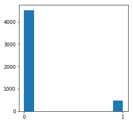

```python
fig, ax = plt.subplots(figsize=(4,4))
ax.hist(pLoan['Personal Loan'])
ax.locator_params(axis='x', integer=True)
```

### Influence of Numerical attributes on Target attribute

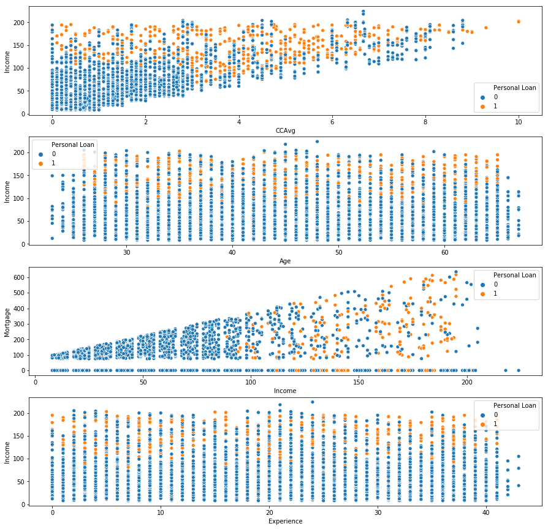

```python
plt.figure(figsize=(15,15))

plt.subplot(4,1,1)
sns.scatterplot(pLoan.CCAvg, pLoan.Income, hue = pLoan['Personal Loan'])

plt.subplot(4,1,2)
sns.scatterplot(pLoan.Age, pLoan.Income, hue = pLoan['Personal Loan'])

plt.subplot(4,1,3)
sns.scatterplot(pLoan.Income, pLoan.Mortgage, hue = pLoan['Personal Loan'])

plt.subplot(4,1,4)
sns.scatterplot(pLoan.Experience, pLoan.Income, hue = pLoan['Personal Loan'])
```

### Deductions:

1. As income crosses 100K, the mortage seems to increase gradually, showing neccessity of Loan.
2. In can been seen that, majority of people with higher CC Avg, tend to have personal loans. Inother words, Customers who have personal loans tend to have higher CCAvg.

### Influence of Categorical attributes on Target attribute

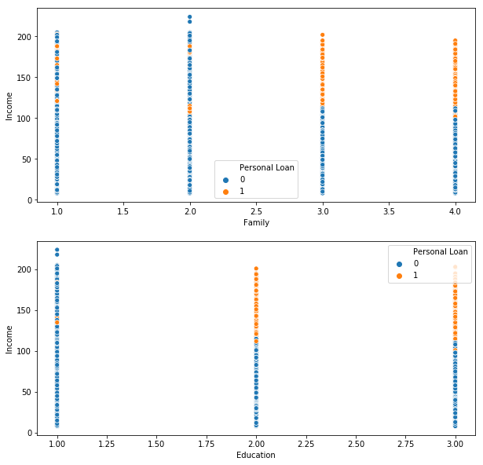

```python
plt.figure(figsize=(10,10))

plt.subplot(2,1,1)
sns.scatterplot(pLoan.Family, pLoan.Income, hue = pLoan['Personal Loan'])

plt.subplot(2,1,2)
sns.scatterplot(pLoan.Education, pLoan.Income, hue = pLoan['Personal Loan'])
```

### Deductions:

1. As family members are greater than 3, the neccessity of personal loan increases.
2. People with graduate or higher education with higher incomes,tend to have personal loans

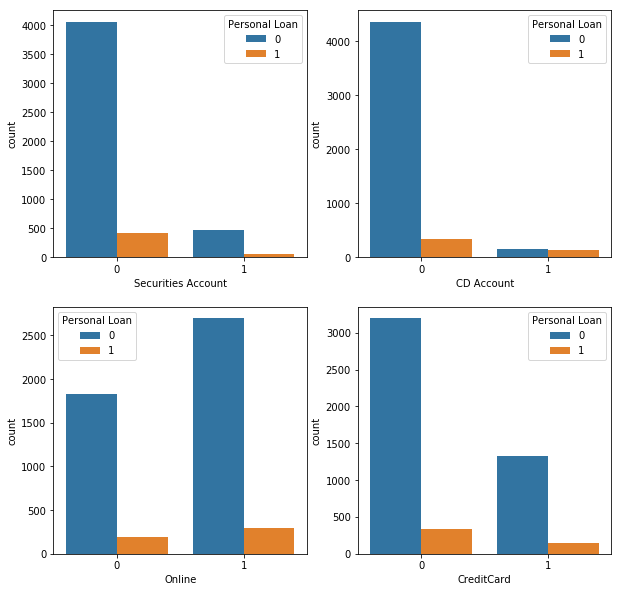

```python
plt.figure(figsize=(10,10))

plt.subplot(2,2,1)
sns.countplot(x="Securities Account", data=pLoan ,hue="Personal Loan")

plt.subplot(2,2,2)
sns.countplot(x='CD Account' ,data=pLoan ,hue='Personal Loan')

plt.subplot(2,2,3)
sns.countplot(x='Online' ,data=pLoan ,hue='Personal Loan')

plt.subplot(2,2,4)
sns.countplot(x='CreditCard' ,data=pLoan ,hue='Personal Loan')
```

```python
# Checking for correlation

pLoan.drop(['ID','ZIP Code'], axis=1).corr().round(decimals=3)
```

|  | Age | Experience | Income | Family | CCAvg | Education | Mortgage | Personal Loan | Securities Account | CD Account | Online | CreditCard |
| --- | --- | --- | --- | --- | --- | --- | --- | --- | --- | --- | --- | --- |
| Age | 1.000 | 0.977 | -0.055 | -0.046 | -0.052 | 0.041 | -0.013 | -0.008 | -0.000 | 0.008 | 0.014 | 0.008 |
| Experience | 0.977 | 1.000 | -0.049 | -0.046 | -0.049 | 0.018 | -0.013 | -0.014 | -0.000 | 0.006 | 0.013 | 0.009 |
| Income | -0.055 | -0.049 | 1.000 | -0.158 | 0.646 | -0.188 | 0.207 | 0.502 | -0.003 | 0.170 | 0.014 | -0.002 |
| Family | -0.046 | -0.046 | -0.158 | 1.000 | -0.109 | 0.065 | -0.020 | 0.061 | 0.020 | 0.014 | 0.010 | 0.012 |
| CCAvg | -0.052 | -0.049 | 0.646 | -0.109 | 1.000 | -0.136 | 0.110 | 0.367 | 0.015 | 0.137 | -0.004 | -0.007 |
| Education | 0.041 | 0.018 | -0.188 | 0.065 | -0.136 | 1.000 | -0.033 | 0.137 | -0.011 | 0.014 | -0.015 | -0.011 |
| Mortgage | -0.013 | -0.013 | 0.207 | -0.020 | 0.110 | -0.033 | 1.000 | 0.142 | -0.005 | 0.089 | -0.006 | -0.007 |
| Personal Loan | -0.008 | -0.014 | 0.502 | 0.061 | 0.367 | 0.137 | 0.142 | 1.000 | 0.022 | 0.316 | 0.006 | 0.003 |
| Securities Account | -0.000 | -0.000 | -0.003 | 0.020 | 0.015 | -0.011 | -0.005 | 0.022 | 1.000 | 0.317 | 0.013 | -0.015 |
| CD Account | 0.008 | 0.006 | 0.170 | 0.014 | 0.137 | 0.014 | 0.089 | 0.316 | 0.317 | 1.000 | 0.176 | 0.279 |
| Online | 0.014 | 0.013 | 0.014 | 0.010 | -0.004 | -0.015 | -0.006 | 0.006 | 0.013 | 0.176 | 1.000 | 0.004 |
| CreditCard | 0.008 | 0.009 | -0.002 | 0.012 | -0.007 | -0.011 | -0.007 | 0.003 | -0.015 | 0.279 | 0.004 | 1.000 |

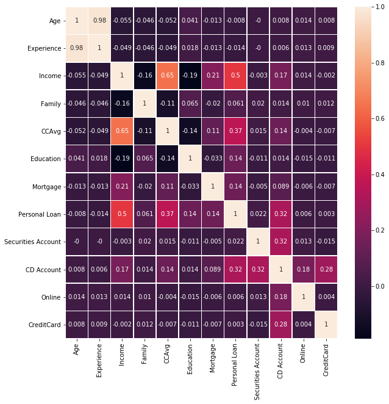

```python
fig, ax = plt.subplots(figsize=(10,10))
sns.heatmap(pLoan.drop(['ID','ZIP Code'], axis=1).corr().round(decimals=3), annot=True, linewidths=0.5, ax=ax)
```

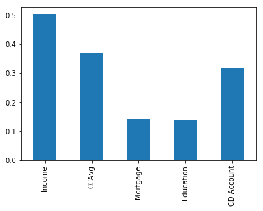

```python
pLoan[['Personal Loan', 'Income', 'CCAvg', 'Mortgage', 'Education', 'CD Account']].corr()['Personal Loan'][1:].plot.bar()
```

### Deductions:

1. Personal Loan seems to have significant postive correlation with Income, CCAvg, CD Account.
2. Age and Experience have a very high Positive correlation with each other.

## 4. Split the data into training and test set in the ratio of 70:30 respectively

```python
#Independant variables.
X = pLoan.drop(['ID','Personal Loan'], axis = 1)

# dependant variables
y = pLoan[['Personal Loan']]

# split X and y into traning and test set in ratio of 70:30

from sklearn.model_selection import train_test_split
X_train, X_test, y_train, y_test = train_test_split(X, y, test_size=0.30, random_state=1)
```

```python
print("No.of rows in train set :", len(X_train))
print("No.of rows in test set  :",len(X_test) )
```

```
No.of rows in train set : 3500
No.of rows in test set  : 1500
```

## 5. Use different classification models (Logistic, K-NN and Naïve Bayes) to predict the likelihood of a customer buying personal loans

### a. Logistic Regression

```python
import warnings
warnings.filterwarnings('ignore')

from sklearn.linear_model import LogisticRegression
logmodel = LogisticRegression(solver='newton-cg')
logmodel.fit(X_train,y_train)
```

```
LogisticRegression(C=1.0, class_weight=None, dual=False, fit_intercept=True,
          intercept_scaling=1, max_iter=100, multi_class='warn',
          n_jobs=None, penalty='l2', random_state=None, solver='newton-cg',
          tol=0.0001, verbose=0, warm_start=False)
```

```python
logistic_predict = logmodel.predict(X_test)
logistic_predictProb = logmodel.predict_proba(X_test)

model_score = logmodel.score(X_test, y_test)
print("Logistic model score:", model_score*100)
```

```
Logistic model score: 94.73333333333333
```

```python
# Classification Report
from sklearn.metrics import classification_report

print(classification_report(y_test, logistic_predict))
```

```
              precision    recall  f1-score   support

           0       0.95      0.99      0.97      1351
           1       0.86      0.56      0.68       149

   micro avg       0.95      0.95      0.95      1500
   macro avg       0.91      0.78      0.83      1500
weighted avg       0.94      0.95      0.94      1500
```

#### The Model Score for Logistic model is 94.74.

**To acheive this we have used 'newton-cg' solver. All the solver were tried and resulted in model score less than the above.**

### b. K-NN

```python
from sklearn.neighbors import KNeighborsClassifier

knn_model = KNeighborsClassifier(n_neighbors=5, weights='distance')
knn_model.fit(X_train, y_train)
```

```
KNeighborsClassifier(algorithm='auto', leaf_size=30, metric='minkowski',
           metric_params=None, n_jobs=None, n_neighbors=5, p=2,
           weights='distance')
```

```python
predicted_labels = knn_model.predict(X_test)
print("K-NN Model score wiht (K-value=5) is :", knn_model.score(X_test, y_test)*100)
```

```
K-NN Model score wiht (K-value=5) is : 89.2
```

**In the above model, we choose k-value as 5. But We need to find the best k-value. So we select a range of values and capture the scores and pick the k-value that gives the best score.**

```
Best score: 90.4
Best k-value: 28
```

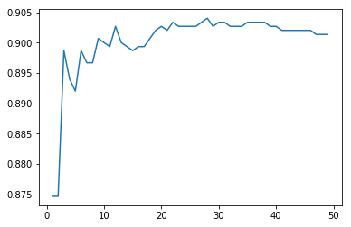

```python
scores = {} #dictornary to capture the model score acorss each k-value
for k in range(1,50):
    knn_model = KNeighborsClassifier(n_neighbors = k, weights = 'distance')
    knn_model.fit(X_train, y_train)
    scores[k]=knn_model.score(X_test, y_test)

plt.plot(range(1,50),scores.values())

best_score = max(scores.values())
print('Best score:',best_score*100)

best_k = max(scores, key=lambda k: scores[k])
print('Best k-value:',best_k)
```

#### As seen from the above graph and the outputs, the best k-value = 28 with returns a model score of 90.4

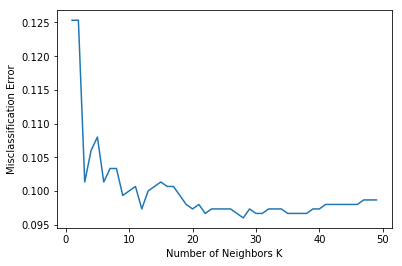

```python
# Misclassification error.

# we try to plot the misclassification error for each of the model corresponding a k-value

knn_model = KNeighborsClassifier(n_neighbors=5, weights='distance')
knn_model.fit(X_train, y_train)
predicted_labels = knn_model.predict(X_test)

neighbors = range(1,50)

# Changing to misclassification error
MSE = [1 - x for x in scores.values()]

plt.plot(neighbors, MSE)
plt.xlabel('Number of Neighbors K')
plt.ylabel('Misclassification Error')
```

```python
# Classification Report
print(classification_report(y_test, predicted_labels))
```

```
              precision    recall  f1-score   support

           0       0.92      0.97      0.94      1351
           1       0.41      0.19      0.26       149

   micro avg       0.89      0.89      0.89      1500
   macro avg       0.66      0.58      0.60      1500
weighted avg       0.87      0.89      0.87      1500
```

### c. Naive Bayes

```python
from sklearn.naive_bayes import GaussianNB # using Gaussian algorithm from Naive Bayes

# creatw the model
nb_model = GaussianNB()

#train_labels = X_train.pop('Personal Loan')
#test_labels = y_train.pop('Personal Loan')

nb_model.fit(X_train, y_train.values.ravel())
```

```
GaussianNB(priors=None, var_smoothing=1e-09)
```

```python
nb_predict = nb_model.predict(X_test)

from sklearn import metrics

print("Model Accuracy: ", metrics.accuracy_score(y_test, nb_predict)*100)
print()
```

```
Model Accuracy:  88.4
```

```python
# Classififcation Report
print(classification_report(y_test, nb_predict))
```

```
              precision    recall  f1-score   support

           0       0.95      0.92      0.93      1351
           1       0.44      0.57      0.49       149

   micro avg       0.88      0.88      0.88      1500
   macro avg       0.69      0.74      0.71      1500
weighted avg       0.90      0.88      0.89      1500
```

## 6. Confusion Matrix for all Models used above.

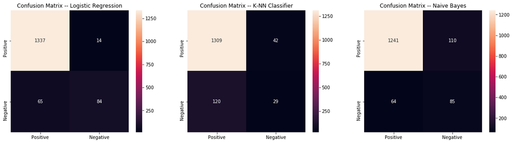

```python
from sklearn.metrics import confusion_matrix

plt.figure(figsize=(20,5))
class_label = ["Positive", "Negative"]
plt.xlabel("Predicted Label")
plt.ylabel("True Label")


plt.subplot(1,3,1)
log_cm = confusion_matrix(y_test, logistic_predict)
df_cm = pd.DataFrame(log_cm, index = class_label, columns = class_label)
sns.heatmap(df_cm, annot = True, fmt='d')
plt.title("Confusion Matrix -- Logistic Regression")

plt.subplot(1,3,2)
knn_cm = confusion_matrix(y_test,predicted_labels)
df_cm1 = pd.DataFrame(knn_cm, index = class_label, columns = class_label)
sns.heatmap(df_cm1, annot = True, fmt = "d")
plt.title("Confusion Matrix -- K-NN Classifier")

plt.subplot(1,3,3)
nb_cm=metrics.confusion_matrix(y_test, nb_predict)
df_cm2 = pd.DataFrame(nb_cm, index = class_label, columns = class_label)
sns.heatmap(df_cm2, annot = True, fmt = "d")
plt.title("Confusion Matrix -- Naive Bayes")
plt.show()
```

## 7. Reasoning on which is the best model in this case and why its better?

```python
Model_Scores = {"Logistic":94.74, "K-NN":90.4, "Naive Bayes" : 88.4}

print("{:<15} {:<5}".format('MODEL','SCORE'))

for v, s in Model_Scores.items():
    print("{:<15} {:<5}".format(v,s))
```

```
MODEL           SCORE
Logistic        94.74
K-NN            90.4
Naive Bayes     88.4
```

**From the above confusion matrix and the model scores, is seems that "Logistic Regression" is the best model for this case, due to its high accuracy**